# Nowcasting: An R Package for Predicting Economic Variables Using Dynamic Factor Models

Serge de Valk

EPGE Brazilian School of Economics and Finance (FGV EPGE)

Daiane Marcolino de Mattos

FGV-IBRE

Pedro Guilherme Costa Ferreira

FGV-IBRE

2019-08-16

Abstract

The [*nowcasting*](https://CRAN.R-project.org/package=nowcasting) package provides the tools to make forecasts of monthly or quarterly economic variables using dynamic factor models. The objective is to help the user at each step of the forecasting process, starting with the construction of a database, all the way to the interpretation of the forecasts. The dynamic factor model adopted in this package is based on the articles from Giannone, Reichlin, and Small (2008) and Banbura, Giannone, and Reichlin (2011). Although there exist several other dynamic factor model packages available for R, ours provides an environment to easily forecast economic variables and interpret results.

# Introduction

Important economic decisions are made based on current and future conditions. Oftentimes, the variables used to measure such conditions are not available even for the recent past. This is, for instance, the case with US GDP that is published 45 days after the end of the quarter. Similarly, Brazilian GDP is published with a 60-day lag. There is therefore a need for forecasting the current value of given variables. To this end, (Giannone, Reichlin, and Small 2008) proposed a statistical model that allows quarterly variables, such as US GDP, to be forecast using a large set of monthly variables released with different lags. GDP forecasts for the current quarter are, furthermore, updated whenever new information is available. Different central banks have shown interest in this methodology, among them the European Central Bank (Angelini et al. 2008; Bańbura and Rünstler 2011; Van Nieuwenhuyze et al. 2008), and the central banks of Ireland (D’Agostino, McQuinn, and O’Brien 2008), New Zealand (Matheson 2010) and Norway (Aastveit and Trovik 2012).

Factor models are designed to summarize the variation contained in a large dataset into only a few variables (James H. Stock and Watson 2006). In (Giannone, Reichlin, and Small 2008), the authors show how to reduce the information contained in dozens of monthly time series into only two dynamic factors. These two estimated factors, which are initially monthly, are then transformed into quarterly factors and used in a regression against GDP. Various other authors, such as (Chauvet 2001; Marcellino, Stock, and Watson 2003; Forni et al. 2004; Boivin and Ng 2006; D’Agostino, Domenico, and Surico 2006; Banbura, Giannone, and Reichlin 2011; Dahlhaus, Guenette, and Vasishtha 2015; J. H. Stock and Watson 2016), have explored Dynamic Factor Models (DFMs) in time series forecasting and found promising results.

Given the publication lag of many variables, such as GDP, we can either forecast past, current or future values. In order to differentiate between those types of forecasts we adopt the terminology used in (Giannone, Reichlin, and Small 2008) and (Banbura, Giannone, and Reichlin 2011). Backcasting refers to forecasting the value of a yet unpublished variable for a past period, while nowcasting will be with respect to the current period. By way of illustration, suppose we want to forecast the GDP for the $2^{nd}$ quarter of 2018. If the exercise is made during the $2^{nd}$ quarter of 2018, then the forecast is classified as nowcasting. However, if the current date is before the $2^{nd}$ quarter of 2018, then the term used is forecasting. Finally, if the date is after the $2^{nd}$ quarter of 2018 and the GDP has not yet been released, then the forecast is classified as backcasting.

The aim of the package *nowcasting* is to offer the tools for the R user to implement dynamic factor models. The different steps in the forecasting process and the associated functions within the package are based on the literature. We have chosen to divide the process into 4 main steps: 1) constructing a dataset; 2) defining the model’s initiation parameters; 3) forecasting; 4) presenting results. This particular division will be maintained in most sections.

This brings us to the article’s sections that are organized as follows: 1) the theoretical framework is introduced; 2) the functions of our package are presented; 3) working examples of how to nowcast Brazilian GDP and of the New York FED nowcasting are given; 4) and finally the last section concludes with some considerations.

# Methodology

## Dynamic Factor Model

Let $x_t = (x_{1,t},x_{2,t}, ..., x_{N,t})^{'}$ be the vector representing $N$ monthly time series transformed to satisfy the weak stationarity assumption. The general specification of the dynamic factor model is given by:

$$\begin{aligned}
x_t &= \mu + \Lambda f_t + \varepsilon_t \label{eq_xt} \\
\end{aligned} (\#eq:eq-xt)$$

$$\begin{aligned}
f_{t} &= \sum_{i=1}^{p} A_i f_{t-i} + B u_t, \quad u_t \sim i.i.d.
N(0,I_q) \label{eq_ft}
\end{aligned} (\#eq:eq-ft)$$

In equation @ref(eq:eq-xt), the variables $x_t$ are expressed as a function of an intercept $\mu$ and $r$ unobserved common factors $f_t$. Since all variables $x$ will later be demeaned, one may drop the unconditional means $\mu$. The variables $x_t$ will be loaded into the unobserved factors $f_t$ through $\Lambda$. Equation @ref(eq:eq-ft) imposes the structure of a VAR(p) process on the factors $f_t$. Both $\varepsilon_t$ and $u_t$ are normal, allowing the use of the Kalman Filter. Furthermore, the vector of idiosyncratic component $\varepsilon_t$ is unrelated to $u_t$ at all lags, i.e., $E[\epsilon_t u_{t-k}'] = 0$ for any k. An interesting feature of equation @ref(eq:eq-ft) is that the number of shocks $q$ to the factors need not be equal to the number of factors $r$. Structural breaks or lead/lag relationships of the $r$ factors with $q$ common shocks may motivate such a modeling choice (see (J. H. Stock and Watson 2016) for more information).

In the so-called *exact dynamic factor model*, the error components from equation (@ref(eq:eq-xt)) are assumed to be mutually uncorrelated at all lags, i.e., $E[\varepsilon_{i,t} \varepsilon_{j,s}] = 0$ for $i \neq j$. However, following (Banbura, Giannone, and Reichlin 2011), the error term could be modeled as an AR(p’) process:

$$\label{eq_arq}
\varepsilon_{i,t} = \sum_{j=1}^{p'} \alpha_{i,j} \varepsilon_{i,t-j}
+ e_{i,t}, \quad e_{i,t} \sim i.i.d.
N(0,\sigma^2_i) (\#eq:eq-arq)$$

where $E[e_{i,t} e_{j,s}] = 0$ for $i \neq j$.

Following is an example, in matrix form, of equation (@ref(eq:eq-ft)) of the model for orders $r = 2$, $p = 2$ and $q = 2$.

$$\begin{bmatrix}
f_{1,t}\\
f_{2,t}\\
f_{1,t-1}\\
f_{2,t-1}
\end{bmatrix}
=
\begin{bmatrix}
a^1_{1,1} & a^1_{1,2} & a^2_{1,1} & a^2_{1,2} \\
a^1_{2,1} & a^1_{2,2} & a^2_{2,1} & a^2_{2,2} \\
1 & 0 & 0 & 0 \\
0 & 1 & 0 & 0
\end{bmatrix}
\begin{bmatrix}
f_{1,t-1}\\
f_{2,t-1}\\
f_{1,t-2}\\
f_{2,t-2}
\end{bmatrix}
+
\begin{bmatrix}
b_{1,1} & b_{1,2}\\
b_{2,1} & b_{2,2}\\
0 & 0\\
0 & 0
\end{bmatrix}
\begin{bmatrix}
u_{1,t}\\
u_{2,t}
\end{bmatrix}$$

$$F_t
=
\begin{bmatrix}
A_1 & A_2 \\
I_2 & 0
\end{bmatrix}
F_{t-1}
+
B
u_t$$

## Quarterly and monthly variables

In order to predict a quarterly variable using monthly data, we construct a partially observed monthly counterpart of the quarterly variable as proposed in (Mariano and Murasawa 2003). This allows, for instance, quarterly GDP to be explained by monthly variables. Continuing with this example, let $Y_t^M$ be the level of the unobservable monthly GDP level and $Y_t^Q$ the quarterly value of GDP for the partially observable monthly series. As is usual in the literature, we let quarterly GDP be observable in the third month of the quarter.

$$\label{eq::partially observable
quarterly variable}
Y_t^Q = \begin{cases}
Y_t^M + Y_{t-1}^M + Y_{t-2}^M, & t = 3,6,9, \dots\\
\text{unobserved} & \text{ otherwise }
\end{cases} (\#eq:partially-observable-quarterly-variable)$$

The above accounting rule states that the quarterly GDP flow is equal to the sum of the monthly flows. Looking at the quarterly change, $y_t^Q = Y_t^Q - Y_{t-3}^Q$ [^1], it is easy to show that it can be expressed as a function of the differences of the monthly variable, $y_t = Y_t^M - Y_{t-1}^M$, by using equation @ref(eq:partially-observable-quarterly-variable):

$$\begin{split}
y_t^Q &= Y_t^Q - Y_{t-3}^Q \\
&= Y_t^Q + Y_{t-1}^Q - Y_{t-1}^Q + Y_{t-2}^Q - Y_{t-2}^Q -
Y_{t-3}^Q\\
&= y_t + 2y_{t-1} + 3y_{t-2} + 2y_{t-3} + y_{t-4}, \quad t =
6,9, \dots
\end{split}$$

Suppose that the variable of interest is a quarterly rate of change, $x_t^Q$, defined as:

$$\label{eq::quarterly growth}
x_t^Q \equiv \log(Y_t^Q) -
\log(Y_{t-3}^Q) (\#eq:quarterly-growth)$$

Stating the approximation between the arithmetic and geometric means we have:
$$\label{eq::arithmetic geometric
approximation}
\frac{1}{3}[Y_t^M+Y_{t-1}^M+Y_{t-2}^M] \approx
\sqrt[3]{Y_t^MY_{t-1}^MY_{t-2}^M} (\#eq:arithmetic-geometric-approximation)$$

Combining equations @ref(eq:quarterly-growth) and @ref(eq:arithmetic-geometric-approximation) we obtain the approximation from (Mariano and Murasawa 2003) that expresses the quarterly growth rate of GDP as a function of the unobservable monthly growth rates $x_t^M$:

$$\label{eq:Mariano&Murusawa}
x_t^Q \approx \frac{1}{3} \bigg[x_t^M + 2x_{t-1}^M + 3x_{t-2}^M +
2x_{t-3}^M + x_{t-4}^M\bigg] (\#eq:Mariano&Murusawa)$$

Suppose that the unobserved monthly growth rate $x_t^M$ also admits the same factor representation as in equation @ref(eq:eq-xt) with loadings $\Lambda_Q$, then the quarterly GDP growth rate, $x_t^Q$, can be expressed as a function of monthly factors.

$$\label{eq::quarterly loadings}
x_t^Q = \overline{\Lambda_{Q}} \ \bigg[f'_t \ \dots \
f_{t-4}'\bigg]' + \bigg[1 \ 2 \ 3 \ 2 \ 1 \bigg]
\bigg[\varepsilon_t^M \ \dots \
\varepsilon_{t-4}^M\bigg]' (\#eq:quarterly-loadings)$$

where $\overline{\Lambda_{Q}} = [\Lambda_Q \ 2\Lambda_Q \ 3\Lambda_Q \ 2\Lambda_Q \ \Lambda_Q]$ is a restricted matrix of loadings on the factors and their lags. Note that the errors are normal in the exact dynamic factor model or have an AR(1) structure as in (Banbura, Giannone, and Reichlin 2011).

## Determining the number of factors and shocks to the factors

We follow the papers by Bai and Ng (2002) and Bai and Ng (2007) to respectively define 1) the number $r$ of factors in equation (@ref(eq:eq-xt)) and 2) the number of shocks $q$ to the factors in equation (@ref(eq:eq-ft)).

Let $V(r,\hat{F}^r)$ be the sum of squared residuals when $r$ factors are estimated using principal components. The the information criteria can then be written as follows:

$$\label{eq_ICP1}
IC_{r1}(r) = ln(V(r,\widehat{F}^r)) +
r\bigg(\frac{N+T}{NT}\bigg)ln\bigg(\frac{NT}{N+T}\bigg) (\#eq:eq-ICP1)$$

$$\label{eq_ICP2}
IC_{r2}(r) = ln(V(r,\widehat{F}^r)) +
r\bigg(\frac{N+T}{NT}\bigg)ln\big(\min\{N,T\}\big) (\#eq:eq-ICP2)$$

$$\label{eq_ICP3}
IC_{r3}(r) = ln(V(r,\widehat{F}^r)) +
r\bigg(\frac{ln(\min\{N,T\})}{min\{N,T\}}\bigg) (\#eq:eq-ICP3)$$

The chosen number of factors $r^*$ will then correspond to $\arg \min_r IC_{ri}(r)$, for $i \in \{1,2,3\}$. Equations (@ref(eq:eq-ICP1)), (@ref(eq:eq-ICP2)), and (@ref(eq:eq-ICP3)) are asymptotically equivalent, but may nevertheless give significantly different results for finite samples. To this effect, observe that the penalty in equation (@ref(eq:eq-ICP2)) is highest when considering finite samples.

The number of shocks `q` can be lower than the number of factors `r`. Once the number of factors is determined, we use an information criterion from Bai and Ng (2007) to estimate the number of shocks $q$ in equation (@ref(eq:eq-ft)). Let $\widehat{F}_t$ be the $r$ factors estimated using principal components and let $\widehat{u}_t$ be the residuals from the VAR $A(l) \widehat{F}_t = \widehat{u}_t$. The idea is to check whether the eigenvalues of the variance-covariance matrix $\widehat{\sum}_u$ are different from 0. Numerically, we will therefore want to test whether a given eigenvalue is below a predefined tolerance level.To this end, define the eigenvalues $c_1 > c_2 \geq ... \geq c_r \geq 0$ of $\widehat{\sum}_u$ and define the k$^{th}$ normalization of the k+1$^{th}$ eigenvalue

$$\widehat{D}_k =
\bigg(\frac{c^2_{(k+1)}}{\sum^r_{j=1}c^2_j}\bigg)^{1/2}$$

Then for some $0<m<\infty$ and $0<\delta<1/2$ that set the tolerance level, define the vector K

$$\label{ICQ3}
\textit{K} = \{k: \widehat{D}_k < m/
\min[N^{1/2-\delta},T^{1/2-\delta}] \} (\#eq:ICQ3)$$

where the estimated number of shocks to the factors will be $\hat{q} = \min \{ k \in \textit{K}\}$. This estimator will converge in probability towards the real number of shocks given that $r$ is the real number of factors.

## Estimation

We will describe two methodologies for estimating dynamic factors: *Two-Stage* and *Expectation-Maximization*.

1. *Two-Stage*: This approach is described in (Giannone, Reichlin, and Small 2008) and refers to the exact DFM. In the first stage, the parameters of the matrices $\Lambda$ and $f_t$ are estimated by Principal Components Analysis (PCA) using a standardized, balanced panel ($\overline{X}_t$), in which there are no missing values and outliers. Standardization is important as PCA is not scale invariant. The estimators $\widehat\Lambda$ and $\widehat{f}_t$ can be obtained by solving the following optimization problem:

   $$\label{otimiza_ft}
   \min_{f_1,...,f_T,\Lambda} \frac{1}{NT} \sum_{t=1}^T (\overline{X}_t
   -\Lambda f_t)'(\overline{X}_t -\Lambda f_t) \quad s.t. \quad N^{-1}
   \Lambda'\Lambda = I_r (\#eq:otimiza-ft)$$

   The estimator for the variance and covariance matrix for $\varepsilon_t$ is then given by

   $$\widehat{\Psi} = diag\Bigg(\frac{1}{T}
   \sum_{t=1}^T (\overline{X}_t -\widehat{\Lambda}
   \widehat{f}_t)(\overline{X}_t -\widehat{\Lambda}
   \widehat{f}_t)'\Bigg)$$

   According to (James H. Stock and Watson 2011), the solution to (@ref(eq:otimiza-ft)) is to set $\widehat{\Lambda}$ equal to the eigenvectors of the variance and covariance matrix of $\overline{X}_t$ associated with the $r$ largest eigenvalues, from which it follows that the vector $\widehat{f_t}$ is the $r$ first principal components of $\overline{X}_t$. The coefficients of the matrix $A_i$, $i = 1,2,...,p,$ from equation @ref(eq:eq-ft), are estimated by OLS regression of $f_t$ on $f_{t-1},...,f_{t-p}$. Finally, $BB'$ is estimated as the covariance matrix of the residuals of this regression.

   In the second stage, Kalman smoothing (Durbin and Koopman 2012) is used to re-estimate the factors for the unbalanced panel $x_t$ considering the parameters obtained in the previous step. There are some R packages that implemented the Kalman smoothing (Tusell 2011). However, for convenience, in the *nowcasting* package, we used the routine provided by (Giannone, Reichlin, and Small 2008). Furthermore, two options are provided when estimating the factors:
   - *No aggregation*: No bridge equation, to obtain @ref(eq:reg), is needed if both the dependent and the explanatory variables are monthly indicators. Hence, the aggregation procedure as set out in (Mariano and Murasawa 2003) is not required. Similarly, if the explanatory variables have been transformed to represent quarterly quantities, the same aggregation procedure does not need to be implemented again on the factors.
   - *With aggregation*: This option is relevant when having a dependent variable `y` of lower frequency than the explanatory variables. Factors are estimated using the monthly explanatory variables $x$, after which the transformation from (Mariano and Murasawa 2003) is applied in order to obtain factors representing quarterly quantities. Those will be used to forecast the dependent variable in the bridge equation @ref(eq:reg).

   $$\label{reg}
   y_t = \beta_0 + \beta' \widehat{f}_t +
   e_t (\#eq:reg)$$

   The parameters of equation @ref(eq:reg) are estimated by OLS, and the forecast for $y_{t+h}$ is given by

   $$\widehat{y}_{t+h} = \widehat{\beta_0} +
   \widehat{\beta}' \widehat{f}_{t+h}$$
2. Expectation-Maximization: This estimation method is able to deal with arbitrary patterns of missing values as shown in (Bańbura and Modugno 2014). It is therefore less restrictive than the *Two-Stage* method with regards to the frequencies of the variables and allows for a mixed frequency database. Following (Banbura, Giannone, and Reichlin 2011), factors can be defined for different subgroups of variables and no longer all need to be global as in the *Two-Stage* estimation method. Below, we illustrate a case where three factors are partitioned into three groups (global, real and nominal) as in (Banbura, Giannone, and Reichlin 2011). Rewriting equation @ref(eq:eq-xt) accordingly gives equation @ref(eq:block-structure). As opposed to the *Two-Stage* estimation method that builds on an exact dynamic factor model, the error term is defined as an AR(1) process. A more restrictive assumption than the *Two-Stage* method is that the number of shocks to the factors `q` is set equal to the number of factors `r`.

   $$\label{eq::block_structure}
   x_t = \mu + \begin{pmatrix}
   \Lambda_{N,G} & \Lambda_{N,N} & 0\\
   \Lambda_{R,G} & 0 & \Lambda_{R,R}
   \end{pmatrix}
   \begin{pmatrix}
   f_t^G \\z
   f_t^N \\
   f_t^R
   \end{pmatrix} + \varepsilon_t\\ (\#eq:block-structure)$$

   where

   $$\begin{pmatrix}
   \Lambda_{N,G} & \Lambda_{N,N} & 0\\
   \Lambda_{R,G} & 0 & \Lambda_{R,R}
   \end{pmatrix} = \Lambda\\$$

   $$\begin{pmatrix}
   f_t^G \\
   f_t^N \\
   f_t^R
   \end{pmatrix} = f_t\\$$

   The global factor is estimated considering all the explanatory variables, while the estimates of the nominal and real factors only consider variable classified, respectively, as nominal and real. The parameter $\mu$ is a vector of constants of dimension N. As previously mentioned, the alternative proposed by (Banbura, Giannone, and Reichlin 2011) to the exact DFM, allows for serial autocorrelation among the error of equation @ref(eq:eq-xt) along an $AR(1)$ process:

   $$\varepsilon_{i,t} = \alpha_i
   \epsilon_{i,t-1} + e_{i,t}, \quad e_{i,t} \sim i.i.d.
   N(0,\sigma_i^2)$$
   where $E[e_{i,t} e_{j,s}] = 0$ for $i \neq j$.

   In this model, the parameters, the unobserved common factors and the missing values are estimated through the *Expectation-Maximization* algorithm, which uses the following recursive structure:
   - E-step: The conditional expectation of the likelihood function is calculated using the estimates of the static parameters ($\theta$) from the previous iteration, $\theta_j$;
   - M-step: The new parameters, $\theta_{j+1}$ are estimated by maximizing the likelihood function from the previous step with respect to $\theta$.

   Convergence is achieved when the absolute change in the value of the log-likelihood function is less than $10^{-4}$, the tolerance level used for this algorithm. The recursive process starts with the PCA estimates given in (Giannone, Reichlin, and Small 2008) (first stage of the *Two-Stage* method).

# The R package

## Working on the dataset

The first step in the nowcasting process is to prepare the data in a way that is compatible with the proposed models and estimation methods. One of the motivations of the presented models is the forecasting improvements that can be achieved by using higher frequency variables. More specifically, the gains that can be obtained in using monthly variables to forecast quarterly series. Hence, all functions require monthly `mts` objects. In practice, the quarterly variables are usually represented as monthly variables for which the last month of the quarter is observed. As illustrated in the working examples, such straightforward transformations from one frequency representation to another can be achieved by using the functions `qtr2month()` or `month2qtr()`.

With regards to the estimation methods, different inputs may have to be provided. As a matter of fact, the *Two-Stage* method is more restrictive on the format of the variables as it depends on principal components in the first stage. This requires a strategy to deal with missing values, which are not part of the jagged edge, beforehand. (Giannone, Reichlin, and Small 2008) propose to replace such missing values with the median of the series that are then smoothed with a moving average. Since such a strategy assigns a value that is independent of the information contained in other contemporaneous variables, it is advisable to exclude series with many missing values. The *EM algorithm*, however, is able to deal with missing values in a way that uses the information contained in other variables and might therefore not require discarding such variables. Finally, independently of the estimation method, stationary series are required. The usual transformations for making time series stationary and the different strategies to deal with missing values have been included in the function `Bpanel()` that prepares the database for the nowcasting function. Since these choices require careful attention, the function `Bpanel()` is explained in further detail.

```r
Bpanel(base, trans, NA.replace = TRUE, aggregate = FALSE, k.ma = 3, na.prop = 1/3, h = 12)
```

**`trans`**

is a vector indicating the transformations to be applied to the variables. For most cases, the available transformations are sufficient to make economic variables stationary. The transformation must be specified by using one of the following values for the argument `trans`:

1. `trans = 0`: the observed series is preserved;
2. `trans = 1`: monthly rate of change: $\displaystyle\frac{x_{i,t} - x_{i,t-1}}{x_{i,t-1}}$;
3. `trans = 2`: monthly difference: $x_{i,t} - x_{i,t-1}$;
4. `trans = 3`: monthly difference in year-over-year rate of change:
   $$\displaystyle\frac{x_{i,t} -
   x_{i,t-12}}{x_{i,t-12}} - \frac{x_{i,t-1} -
   x_{i,t-13}}{x_{i,t-13}};$$
5. `trans = 4`: monthly difference in year-over-year difference:
   $$(x_{i,t} - x_{i,t-12}) -
   (x_{i,t-1} - x_{i,t-13}).$$
6. `trans = 5`: year difference:
   $$(x_{i,t} - x_{i,t-12})$$
7. `trans = 6`: year-over-year rate of change:
   $$\frac{x_{i,t} -
   x_{i,t-12}}{x_{i,t-12}}$$
8. `trans = 7`: quarterly rate of change
   $$\frac{x_{i,t} -
   x_{i,t-3}}{x_{i,t-3}}$$

**`NA.replace`**

is a boolean to determine whether missing values should be replaced (`NA.replace = TRUE`) or not (`NA.replace = FALSE`).

**`aggregate`**

is a boolean to indicate whether to aggregate the monthly variables to represent quarterly quantities. If `TRUE` the aggregation is made following the approximation of (Mariano and Murasawa 2003).

**`k.ma`**

is a numeric representing the degree of the moving average correction if `NA.replace = TRUE`.

**`na.prop`**

is a number between 0 and 1 indicating the ratio of missing observations to the total number of observations beyond which series will be discarded. The default is 1/3, meaning that if more than 1/3 of the observations are missing the series will be discarded from the database.

**`h`**

indicates how many periods should be added to the database. Default is 12. Those missing values will be predicted with the function `nowcast()`.

## Determining the number of factors and shocks to the factors

As explained in the section on parameter estimation, the package offers different functions to estimate the number of factors $r$ and of idiosyncratic shocks $q$ of equations (@ref(eq:eq-xt)) and (@ref(eq:eq-ft)) respectively.

1. Function `ICfactors()` estimates the number of factors $r^*$ according to an information criterion. The argument `x` is a balanced panel and `rmax` is an integer representing the maximum number of factors for which the information criterion should be calculated. The default value is 20. `type` indicates which of the information criterion from Bai and Ng (2002) to use. `type` $\in \{1,2,3\}$ with the default being 2 as explained in the methodological section. If `x` is not a balanced panel, the function will delete rows with missing values in order to use principal components.

   ```r
   ICfactors(x, rmax = 20, type = 2)
   ```

2. Function `ICshocks()` estimates the number of idiosyncratic shocks given a number $r$ of factors according to the information criterion introduced in the previous section. The argument `x` is a balanced panel. `delta` and `m` are parameters of the information criterion, where $0<m<\infty$ and $0<\delta<1/2$. The default values are those from Bai and Ng (2007): $m=1$ and $\delta = 0.1$. If the number of factors `r` is not specified it will be defined according to `ICfactors(x, rmax = 20, type = 2)`. `p` is the number of lags in the VAR of equation (@ref(eq:eq-ft)). If not specified, the default is the lowest most occurring value from the information criteria used within the function `VARselect()` from the package *vars*.

   ```r
   ICshocks(x, r = NULL, p = NULL, delta = 0.1, m = 1)
   ```

## Forecasts

An important feature of factor models is the dimensionality reduction of (many) original variables into a few common factors. Hence, the target variable `y` will be expressed as a function of a few factors extracted from the explanatory variables. This motivated the choice of the inputs for the `nowcast()` function. The formula format, which is well known to R users, captures this idea as `formula = y`$\sim$`.` can be understood as the projection of `y` on the information contained in the dataset. The model’s parameters are estimated according to the selected method (`2s`, `2s_agg` and `EM`, which correspond, respectively, to “two-stage”, “two-stage with factor aggregation” and “Expectation-Maximization algorithm”) described in the section on estimation. The number `r` of dynamic factors, the number `q` of shocks to the factors, and the lag order `p` of the factors are determined beforehand as shown in the previous subsection. The argument `blocks` can be used with the `EM` method to estimate factors for different subgroups of variables. Finally, the argument `frequency` is necessary for all methods in order to identify the frequency of the variables.

```r
nowcast(formula, data, q = NULL, r = NULL, p = NULL, method = 'EM', blocks = NULL,
        frequency = NULL)
```

In the first two methods (`2s` and `2s_agg`), the factors are calculated based on the monthly variables, on which the dependent variable `y` will be regressed. The difference between `2s` and `2s_agg` is that for the latter the monthly factors are transformed into quarterly quantities while in the former no such aggregation is used. A linear regression (*bridge equation* if `y` is quarterly) of `y` on the factors allows the former to be forecast.

In the third method (`EM`) no bridge equation is needed, as opposed to the *Two-Stage* method. In practice, the algorithm will estimate all the missing values respecting the restrictions imposed by equation @ref(eq:quarterly-loadings). The forecasts of quarterly time series are defined as the estimated values of the third month of the out of sample quarters. As opposed to the *Two-Stage* method, the number of common shocks `q` can not be specified and is assumed to be equal to `r`, the number of factors in each block.

## Analyzing the results

The function `nowcast.plot()` allows to plot several outputs from the function `nowcast()`.

```r
nowcast.plot(out, type = "fcst")
```

The argument `out` is the output from the function `nowcast()`. The argument `type` can be chosen from the list {"fcst","factors","eigenvalues","eigenvectors"}:

- `"fcst"`: shows the `y` variable and its forecasts in sample and out of sample.
- `"factors"`: shows all the estimated factors.
- `"eigenvalues"`: indicates how much of the variability in the dataset is explained by each factor.
- `"eigenvectors"`: shows the importance of each variable in the first factor.

# A working example of the *Two-Stage* method: nowcasting Brazilian GDP

## Constructing the dataset

In this example we showcase how to nowcast Brazilian GDP using the *Two-Stage* estimation method. Most of the variables of interest can be downloaded from the Brazilian central bank using the function `BETSget()` from the package *BETS*. The variables and the associated codes can be found on the Brazilian central bank’s website [^2]. For the sake of simplicity we have included the database, and all relevant information within the package[^3].

```r
> library(nowcasting)
> data(BRGDP)
```

For this example we will construct a pseudo real-time dataset, using the function `PRTDB()`. Some variables, such as GDP, suffer revisions over time. Since we do not take revisions into account, we refer to such datasets as pseudo real-time (as opposed to vintages). The (approximate) delays in days are included in the `BRGDP` object and will be used to define if observations were available at a specific moment in time. The dataset is then treated for outliers and missing values that are not part of the jagged edges of the data, i.e., that are not due to the different publication lags of the variables. This is achieved through the function `Bpanel()`. Unless otherwise specified by the user, the function will also discard series with over 1/3 missing values.

```r
> vintage <- PRTDB(mts = BRGDP$base, delay = BRGDP$delay, vintage = "2015-06-01")
> base <- window(vintage, start = c(2005,06), frequency = 12)
> x <- Bpanel(base = base, trans = BRGDP$trans)
```

The function `month2qtr()` transforms monthly time series into quarterly ones. In this case we want to use the value of the third month as the quarterly value.

```r
> GDP <- base[,which(colnames(base) == "PIB")]
> window(GDP, start = c(2015,1))
        Jan    Feb    Mar    Apr    May    Jun
2015     NA     NA 170.68     NA     NA     NA
```

```r
> GDP_qtr <- month2qtr(x = GDP, reference_month = 3)
> window(GDP_qtr, start = c(2015,1))
       Qtr1   Qtr2
2015 170.68     NA
```

The quarterly GDP indicator, in this example, is an index representing the seasonal quarterly product. $\Delta_4Y_t$ deals with seasonality, while $\Delta\Delta_4Y_t$ is necessary to obtain a stationary time series. To test the latter, one could look at tests for unit roots or serial auto correlation that are included in many R packages.

```r
> y <- diff(diff(GDP_qtr,4))
> y <- qtr2month(y)
```

## Determining the number of factors and shocks

The dataset `x`, which now only posses jagged edges, is well suited for the information criteria that make use of principal components. The estimated number of factors is given by the function `ICfactors()`. As explained in the previous section, the information criteria might give different results for finite samples.

```r
> ICR1 <- ICfactors(x = x, type = 1)
```

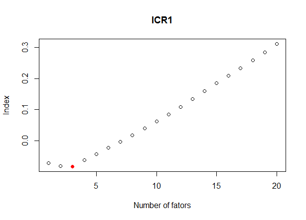

```r
> ICR2 <- ICfactors(x = x, type = 2)
```

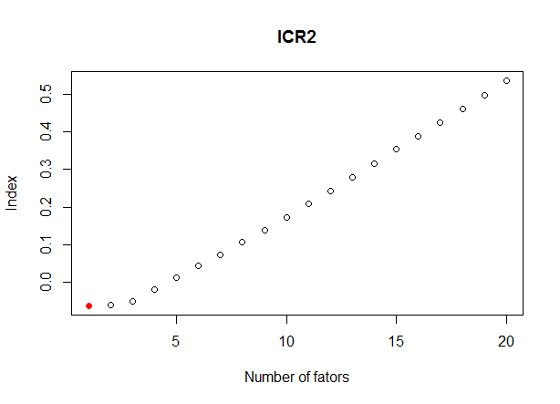

Finally, given the chosen number of factors for our model, we can use an information criterion for determining the number of shocks to the factors.

```r
> ICQ1 <- ICshocks(x = x, r = 2, p = 2)
> ICQ1$q_star
[1] 2
```

## Forecasts

Let the object `data` be a monthly `mts` object where the first column is a partially observable stationary GDP series (`y`) and the remaining columns a balanced panel of stationary time series (`x`). The `frequency` vector will be determined by the quarterly GDP series and the remaining monthly series. In this example the factors will be aggregated to obtain quarterly quantities by setting `method = "2s_agg"`.

```r
> data <- cbind(y,x)
> frequency <- c(4,rep(12,ncol(x)))
> now <- nowcast(formula = y~., data = data, r = 2, q = 2 , p = 2, method = "2s_agg",
    frequency = frequency)
> summary(now$reg)

Call:
stats::lm(formula = Y ~ ., data = Balanced_panel)

Residuals:
    Min      1Q  Median      3Q     Max
-3.0248 -0.5679  0.1094  0.5835  1.8912

Coefficients:
            Estimate Std. Error t value Pr(>|t|)
(Intercept) -0.19526    0.16940  -1.153    0.258
Factor1      0.22610    0.01456  15.528  < 2e-16 ***
Factor2      0.06135    0.01174   5.228 1.02e-05 ***
---
Signif. codes:  0 ‘***’ 0.001 ‘**’ 0.01 ‘*’ 0.05 ‘.’ 0.1 ‘ ’ 1

Residual standard error: 1.002 on 32 degrees of freedom
Multiple R-squared:  0.8995,    Adjusted R-squared:  0.8932
F-statistic: 143.1 on 2 and 32 DF,  p-value: < 2.2e-16
```

## Results

The function `nowcast.plot()` enables the user to visualize some of the results. Say, for instance, that we want to look at fitted values and out-of-sample forecasts. This can be achieved by setting the type to `"fcst"`. We might also want to look at the eigenvalues of the normalized variance-covariance matrix of our balanced panel or at how variables enter the first factor.

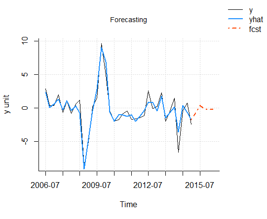

```r
> nowcast.plot(now, type = "fcst")
```

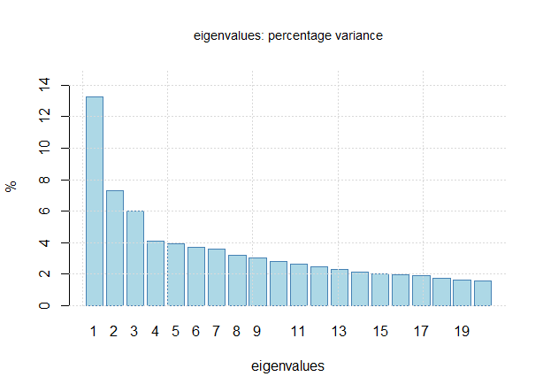

```r
> nowcast.plot(now, type = "eigenvalues")
```

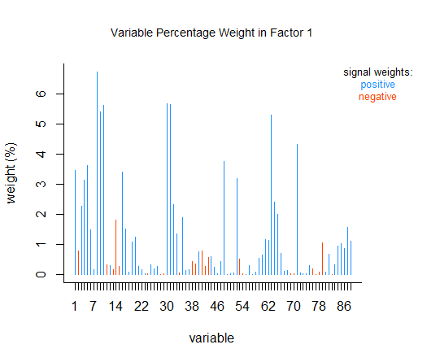

```r
> nowcast.plot(now, type = "eigenvectors")
```

Up until now, we have been forecasting GDP after transforming it into a stationary variable. We might want to transform the former back into a level variable in order to forecast the actual growth rate. Remember that we transformed GDP according to

$$\begin{split}
diff(diff(GDP_t,4)) & = (GDP_t - GDP_{t-4}) - (GDP_{t-1} -
GDP_{t-5}) \\
& = GDP_t + GDP_{t-5} - GDP_{t-1} - GDP_{t-4}
\end{split}$$

that can be rewritten as

$$\label{y_fcst}
GDP_t = diff(diff(GDP_t,4)) - GDP_{t-5} + GDP_{t-1} +
GDP_{t-4} (\#eq:y-fcst)$$

Equation (@ref(eq:y-fcst)) gives us the forecast of the new quarter GDP level. The variable `BRGDP$GDP` is the non-stationary GDP.

```r
> level_forecast <- na.omit(now$yfcst[,3])[1] - tail(na.omit(GDP_qtr),5)[1] +
+   +   tail(na.omit(GDP_qtr),5)[5] + tail(na.omit(GDP_qtr),5)[2]
> level_forecast
[1] 170.4783
```

```r
> position_q2_2015 <- which(time(BRGDP$GDP) == 2015.25)
> BRGDP$GDP[position_q2_2015]
[1] 169.24
```

# A working example of the *EM* method: The NY FED nowcast

## Constructing the dataset

In this example we work with the data the Federal Reserve of New York made available to reproduce its weekly nowcasting report[^4]. The explanatory variables are mixed frequencies including both monthly and quarterly series.

```r
> library(nowcasting)
> data(NYFED)
> NYFED$legend$SeriesName
 [1] "Payroll Employment"          "Job Openings"
 [3] "Consumer Price Index"        "Durable Goods Orders"
 [5] "Retail Sales"                "Unemployment Rate"
 [7] "Housing Starts"              "Industrial Production"
 [9] "Personal Income"             "Exports"
[11] "Imports"                     "Construction Spending"
[13] "Import Price Index"          "Core Consumer Price Index"
[15] "Core PCE Price Index"        "PCE Price Index"
[17] "Building Permits"            "Capacity Utilization Rate"
[19] "Business Inventories"        "Unit Labor Cost"
[21] "Export Price Index"          "Empire State Mfg Index"
[23] "Philadelphia Fed Mfg Index"  "Real Consumption Spending"
[25] "Real Gross Domestic Product"
```

Similarly to the previous working example, the object `NYFED` contains all the necessary information to run the `nowcast()` function. The time series, the block structure, the transformations to make the variables stationary and the variables’ frequencies can be loaded as illustrated below.

```r
> base <- NYFED$base
> blocks <- NYFED$blocks$blocks
> trans <- NYFED$legend$Transformation
> frequency <- NYFED$legend$Frequency
> delay <- NYFED$legend$delay
```

The dataset `data` can be prepared by using the function `Bpanel()`. Using the EM algorithm, there is no need to replace missing values that are not part of the jagged edges, as was the case with the *Two-Stage* method. This can be achieved by setting `NA.replace` to `FALSE`. In this case we do not want to discard series based on a particular ratio of missing values to total observations as was the case in the *Two-Stage* method. This is done by setting `na.prop = 1`, where 1 indicates that only series with more than 100% missing values will be discarded.

```r
> data <- Bpanel(base = base, trans = trans, NA.replace = FALSE, na.prop = 1)
```

## Forecasts

The model´s specifications are the same as those used by the NY FED. We therefore limit the number of factors, `r`, per block to one and define the factor process as a VAR(1), i.e., `p = 1`. The convergence of the log-likelihood function is displayed every 5 iterations.

```r
> nowEM <- nowcast(formula = GDPC1~., data = data, r = 1, p = 1, method = "EM",
    blocks = blocks, frequency = frequency)
5th iteration:
The loglikelihood went from -2418.5983 to -2406.1482
...
65th iteration:
The loglikelihood went from -2354.084 to -2353.8435
```

## Results

Combining the functions `nowcast()` and `PRTB()` within a loop, we illustrate how a pseudo out-of-sample end-of-quarter nowcast can be made. The vector `fcst_dates` defines the last month of the quarters for which quarterly GDP growth will be nowcast. The vector `delay` contains approximate delays, in days, with which variables are published. This enables us to construct a pseudo real-time dataset for a given day.

```r
> fcst_dates <- seq.Date(from = as.Date("2013-03-01"),to = as.Date("2017-12-01"),
        by = "quarter")
> fcst_results <- NULL
> for(date in fcst_dates)\{
+
+   vintage <- PRTDB(data, delay = delay, vintage = date)
+   nowEM <- nowcast(formula = GDPC1~., data = vintage, r = 1, p = 1, method = "EM",
        blocks = blocks, frequency = frequency)
+   fcst_results <- c(fcst_results,tail(nowEM$yfcst[,3],1))
+
+ \}
```

The results of this out-of-sample nowcast example, as well as the results of an out-of-sample ARIMA, are displayed below.

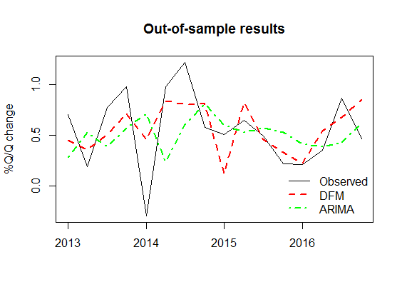

The root mean square prediction error can easily be calculated for the 2013-2016 period. For this given example, when compared to one-period-ahead projections given by an ARIMA model, a Theil’s U statistic of 0.70 is obtained, signaling a 30% improvement over the benchmark.

# Summary

The package *nowcasting* was developed in order to facilitate the use of dynamic factor models for large datasets as set out in Giannone, Reichlin, and Small (2008) and Banbura, Giannone, and Reichlin (2011). The package offers functions at each step of the forecasting process to help the user treat data, choose and estimate the value of parameters, as well as interpret results. We provided a working example for nowcasting Brazilian GDP, illustrating each step and showing how to implement the various functions available. We also used the New York FED nowcasting exercise to illustrate the EM algorithm. We will, in the future, work on adding new tools for the user to better leverage the `EM` method by identifying the source of forecast revisions. As shown by the New York FED nowcasting report, this is an interesting policy instrument that helps contextualizing forecast updates.

# Acknowledgements

We thank Daniel Mesquita for revising some of the codes and our colleagues from FGV-IBRE for helpful inputs. We also thank an anonymous referee and the R journal editor Olivia Lau for constructive comments. The authors are responsible for any errors in this paper. This study was financed in part by the Coordenação de Aperfeiçoamento de Pessoal de Nível Superior - Brasil (CAPES) - Finance Code 001.

Aastveit, Knut Are, and Tørres Trovik. 2012. “Nowcasting Norwegian GDP: The Role of Asset Prices in a Small Open Economy.” *Empirical Economics* 42 (1): 95–119. https://doi.org/10.1007/s00181-010-0429-9.

Angelini, Elena, Gonzalo Camba-Mendez, Domenico Giannone, Lucrezia Reichlin, and Gerhard Rünstler. 2008. “Short-Term Forecasts of Euro Area GDP Growth.” Working Papers ECARES ECARES 2008-035. ULB – Universite Libre de Bruxelles. https://ideas.repec.org/p/eca/wpaper/2008_035.html.

Bai, Jushan, and Serena Ng. 2002. “Determining the Number of Factors in Approximate Factor Models.” *Econometrica* 70 (1): 191–221. https://doi.org/10.1111/1468-0262.00273.

———. 2007. “Determining the Number of Primitive Shocks in Factor Models.” *Journal of Business & Economic Statistics* 25 (1): 52–60. https://doi.org/10.1198/073500106000000413.

Banbura, Marta, Domenico Giannone, and Lucrezia Reichlin. 2011. “Nowcasting.” *Oxford Handbook on Economic Forecasting*.

Bańbura, Marta, and Michele Modugno. 2014. “Maximum Likelihood Estimation of Factor Models on Datasets with Arbitrary Pattern of Missing Data.” *Journal of Applied Econometrics* 29 (1): 133–60. https://doi.org/10.1002/jae.2306.

Bańbura, Marta, and Gerhard Rünstler. 2011. “A Look into the Factor Model Black Box: Publication Lags and the Role of Hard and Soft Data in Forecasting GDP.” *International Journal of Forecasting* 27 (2): 333–46. https://doi.org/10.1016/j.ijforecast.2010.01.011.

Boivin, Jean, and Serena Ng. 2006. “Are More Data Always Better for Factor Analysis?” *Journal of Econometrics* 132 (1): 169–94. https://doi.org/10.1016/j.jeconom.2005.01.027.

Chauvet, Marcelle. 2001. “A Monthly Indicator of Brazilian GDP.” *Brazilian Review of Econometrics* 21 (1): 1–47. https://doi.org/10.12660/bre.v21n12001.3191.

D’Agostino, Antonello, Giannone Domenico, and Paolo Surico. 2006. “(Un)Predictability and Macroeconomic Stability.” Research Technical Papers 5/RT/06. Central Bank of Ireland. https://ideas.repec.org/p/cbi/wpaper/5-rt-06.html.

D’Agostino, Antonello, Kieran McQuinn, and Derry O’Brien. 2008. “Now-Casting Irish GDP.” Research Technical Papers 9/RT/08. Central Bank of Ireland. https://doi.org/10.1787/19952899.

Dahlhaus, Tatjana, Justin-Damien Guenette, and Garima Vasishtha. 2015. “Nowcasting BRIC+m in Real Time.” Staff Working Papers. Bank of Canada. https://doi.org/10.1016/j.ijforecast.2017.05.002.

Durbin, James, and Siem Jan Koopman. 2012. *Time Series Analysis by State Space Methods*. 2nd ed. Oxford University Press. https://EconPapers.repec.org/RePEc:oxp:obooks:9780199641178.

Forni, Mario, Marc Hallin, Marco Lippi, and Lucrezia Reichlin. 2004. “The Generalized Dynamic Factor Model Consistency and Rates.” *Journal of Econometrics* 119 (2): 231–55. https://doi.org/10.1016/s0304-4076(03)00196-9.

Giannone, Domenico, Lucrezia Reichlin, and David Small. 2008. “Nowcasting: The Real-Time Informational Content of Macroeconomic Data.” *Journal of Monetary Economics* 55 (4): 665–76. https://doi.org/10.1016/j.jmoneco.2008.05.010.

Marcellino, Massimiliano, James Stock, and Mark Watson. 2003. “Macroeconomic Forecasting in the Euro Area: Country Specific Versus Area-Wide Information.” *European Economic Review* 47 (1): 1–18. https://doi.org/10.1016/s0014-2921(02)00206-4.

Mariano, Roberto S, and Yasutomo Murasawa. 2003. “A New Coincident Index of Business Cycles Based on Monthly and Quarterly Series.” *Journal of Applied Econometrics* 18 (4): 427–43. https://doi.org/10.1002/jae.695.

Matheson, Troy D. 2010. “An Analysis of the Informational Content of New Zealand Data Releases: The Importance of Business Opinion Surveys.” *Economic Modelling* 27 (1): 304–14. https://doi.org/10.1016/j.econmod.2009.09.010.

Stock, J. H., and M. W. Watson. 2016. *Dynamic Factor Models, Factor-Augmented Vector Autoregressions, and Structural Vector Autoregressions in Macroeconomics*. Vol. 2. Elsevier. https://doi.org/10.1016/bs.hesmac.2016.04.002.

Stock, James H, and Mark Watson. 2011. “Dynamic Factor Models.” *Oxford Handbook on Economic Forecasting*.

Stock, James H, and Mark W Watson. 2006. “Forecasting with Many Predictors.” *Handbook of Economic Forecasting* 1: 515–54. https://doi.org/10.1016/s1574-0706(05)01010-4.

Tusell, Fernando. 2011. “Kalman Filtering in r.” *Journal of Statistical Software, Articles* 39 (2): 1–27. https://doi.org/10.18637/jss.v039.i02.

Van Nieuwenhuyze, Christophe, Karsten Ruth, António Rua, Piotr Jelonek, Audrone Jakaitiene, Ard Den Reijer, Riccardo Cristadoro, Gerhard Rünstler, Szilard Benk, and Karim Barhoumi. 2008. “Short-Term Forecasting of GDP Using Large Monthly Datasets: A Pseudo Real-Time Forecast Evaluation Exercise.” Occasional Paper Series 84. European Central Bank. https://doi.org/10.1002/for.1105.

[^1]: The aggregation scheme, and ensuing weights used for aggregating the monthly series, may differ according to the order of the difference taken. In the paper of (Mariano and Murasawa 2003), the example is of a first difference of quarterly log GDP, which corresponds to a quarterly growth rate. In the case of an annual growth rate, $\Delta_{12} log(Y_t^Q) = log(Y_t^Q) - log(Y_{t-12}^Q)$, the aggregation weights would be different. Such cases are not considered here.
[^2]: see http://www4.bcb.gov.br/pec/series/port/aviso.asp
[^3]: The database is a random sample of 100 variables from our own database
[^4]: https://www.newyorkfed.org/research/policy/nowcast